# Modeling Assignent 3 - Sample Solution

[Nao Mimoto](https://nmimoto.github.io/) - [Dept. of Statistics](http://www.uakron.edu/stat/) : [The University of Akron](http://www.uakron.edu)

[Class Web Page](https://nmimoto.github.io/477/)

% ~/Dropbox/GARAGE/477/CC/Sec5-ARIMA/w12-ModelingAssignment3-sol.R

Load gtemp.csv. from https://nmimoto.github.io/datasets/. The data contains 130 annual global temperature readings. There’s no link on the page, and you have to load it directly to R. Turn the data into ts object in R.

```r
library(forecast)
source('https://nmimoto.github.io/R/TS-00.txt')

Temp = read.csv("https://nmimoto.github.io/datasets/gtemp.csv")
head(Temp)
```

```
##    temp
## 1 -0.28
## 2 -0.21
## 3 -0.26
## 4 -0.27
## 5 -0.32
## 6 -0.32
```

```r
Y = ts(Temp[,1], start=c(1,1), freq=1)
Y
```

```
## Time Series:
## Start = 1
## End = 130
## Frequency = 1
##   [1] -0.28 -0.21 -0.26 -0.27 -0.32 -0.32 -0.29 -0.36 -0.27 -0.17 -0.39 -0.27 -0.32 -0.33
##  [15] -0.33 -0.25 -0.14 -0.11 -0.25 -0.15 -0.07 -0.14 -0.24 -0.30 -0.34 -0.24 -0.19 -0.39
##  [29] -0.33 -0.35 -0.33 -0.34 -0.32 -0.30 -0.15 -0.10 -0.30 -0.39 -0.33 -0.20 -0.19 -0.14
##  [43] -0.26 -0.22 -0.22 -0.17 -0.02 -0.15 -0.12 -0.26 -0.08 -0.02 -0.08 -0.19 -0.07 -0.12
##  [57] -0.05  0.07  0.10  0.01  0.04  0.10  0.03  0.09  0.19  0.06 -0.05  0.00 -0.04 -0.07
##  [71] -0.16 -0.04  0.03  0.11 -0.10 -0.10 -0.17  0.08  0.08  0.06 -0.01  0.07  0.04  0.08
##  [85] -0.21 -0.11 -0.03 -0.01 -0.04  0.08  0.03 -0.10  0.00  0.14 -0.08 -0.05 -0.16  0.12
##  [99]  0.01  0.08  0.18  0.26  0.04  0.26  0.09  0.05  0.12  0.26  0.31  0.19  0.37  0.35
## [113]  0.12  0.13  0.23  0.37  0.29  0.39  0.56  0.32  0.33  0.48  0.56  0.55  0.48  0.62
## [127]  0.54  0.57  0.43  0.57
```

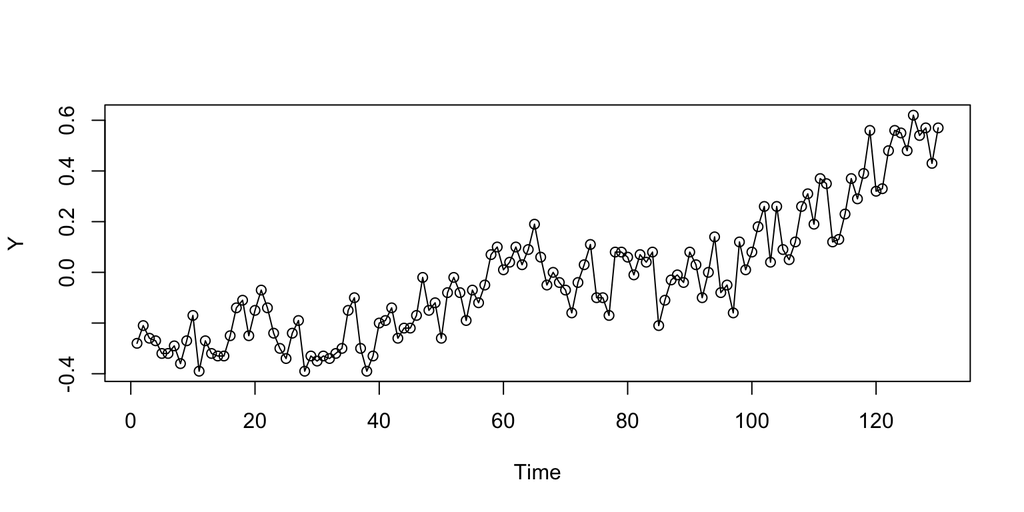

```r
plot(Y, type="o")
```

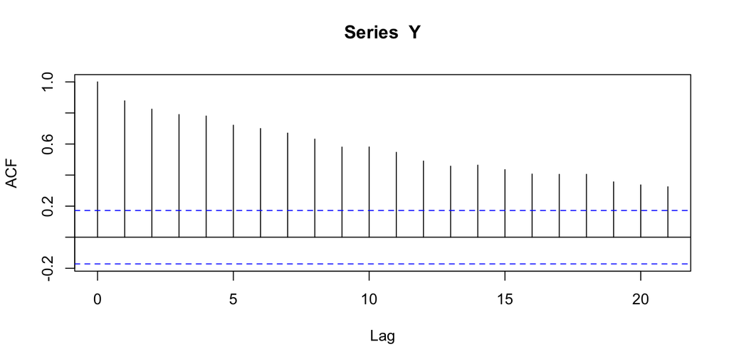

```r
acf(Y)
```

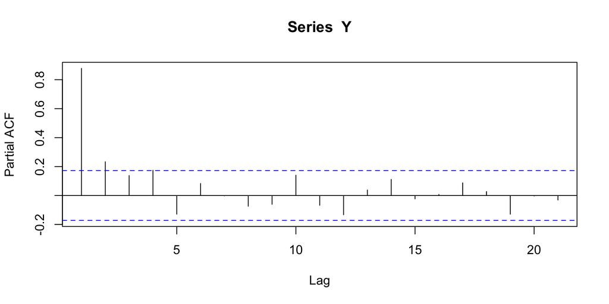

```r
pacf(Y)
```

## a) Perform stationairty analysis

using Stationairty.tests(). What is the right value of $d$ if we are to model this data using ARIMA($p,d,q$)?

```r
Stationarity.tests(Y)
```

```
##        KPSS   ADF   PP
## p-val: 0.01 0.706 0.01
```

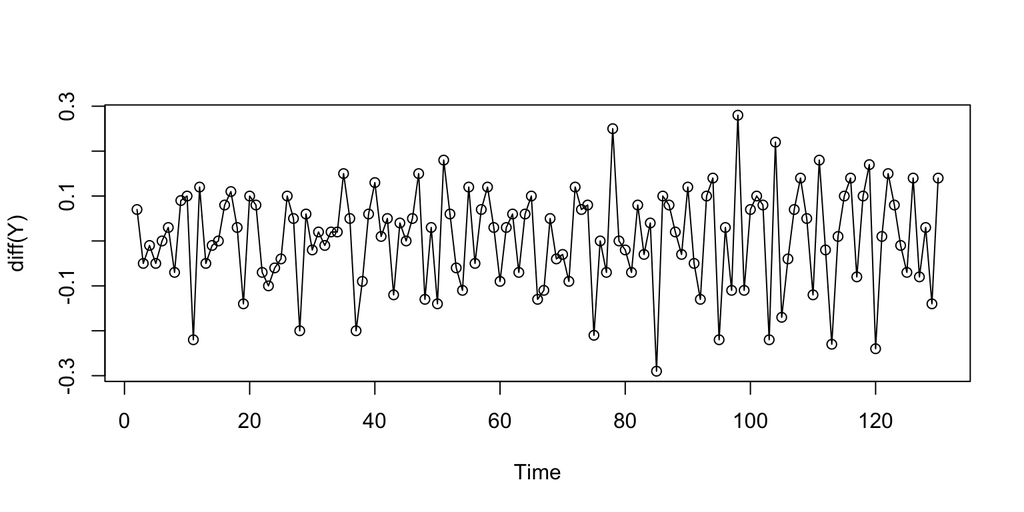

```r
  ## small-large-small.  They are mixed for d=0.

plot(diff(Y), type='o')
```

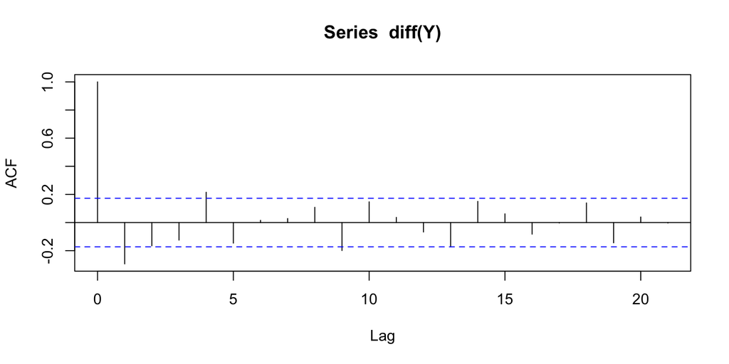

```r
acf(diff(Y))
```

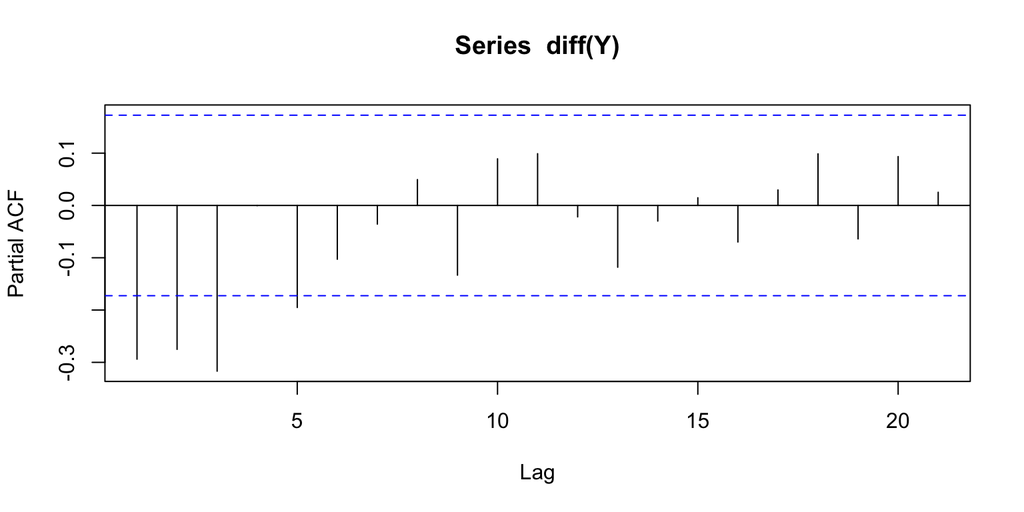

```r
pacf(diff(Y))
```

```r
Stationarity.tests(diff(Y))
```

```
##        KPSS  ADF   PP
## p-val:  0.1 0.01 0.01
```

```r
  ## large-small-small.  Stationary for d=1.
```

## b) Find best ARIMA model

that fits the data, using auto.arima() and Arima(),

```r
FitA1 = auto.arima(Y, d=0, stepwise=FALSE, approximation=FALSE)
FitA1
```

```
## Series: Y
## ARIMA(4,0,1) with zero mean
##
## Coefficients:
##          ar1     ar2     ar3     ar4     ma1
##       0.1824  0.3007  0.1129  0.3709  0.4021
## s.e.  0.3397  0.2318  0.1018  0.0914  0.3751
##
## sigma^2 = 0.009527:  log likelihood = 119.09
## AIC=-226.18   AICc=-225.5   BIC=-208.97
```

```r
  ## ARIMA(4,0,1) with zero mean with bunch of insignificant param.

FitA2 = Arima(Y, order=c(4,0,0), include.mean=FALSE)
FitA2
```

```
## Series: Y
## ARIMA(4,0,0) with zero mean
##
## Coefficients:
##          ar1     ar2     ar3     ar4
##       0.5458  0.0710  0.0700  0.2933
## s.e.  0.0839  0.0968  0.0973  0.0843
##
## sigma^2 = 0.009504:  log likelihood = 118.71
## AIC=-227.41   AICc=-226.93   BIC=-213.07
```

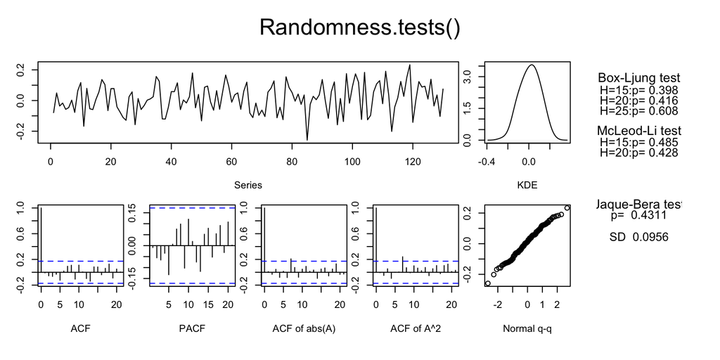

```
##   B-L test H0: the series is uncorrelated
##   M-L test H0: the square of the series is uncorrelated
##   J-B test H0: the series came from Normal distribution
##   SD         : Standard Deviation of the series
```

```
##       BL15  BL20  BL25  ML15  ML20    JB    SD
## [1,] 0.398 0.416 0.608 0.485 0.428 0.431 0.096
```

```r
Randomness.tests(FitA2$residuals)
```

```r
  ## ARIMA(4,0,0) w zero mean passes resid test, but AR2,AR3 insignificant.


FitB1 = auto.arima(Y, d=1, stepwise=FALSE, approximation=FALSE)
FitB1
```

```
## Series: Y
## ARIMA(1,1,3) with drift
##
## Coefficients:
##           ar1     ma1      ma2      ma3   drift
##       -0.9376  0.4846  -0.6341  -0.2857  0.0065
## s.e.   0.0946  0.1165   0.0955   0.0866  0.0025
##
## sigma^2 = 0.009108:  log likelihood = 122.17
## AIC=-232.34   AICc=-231.66   BIC=-215.19
```

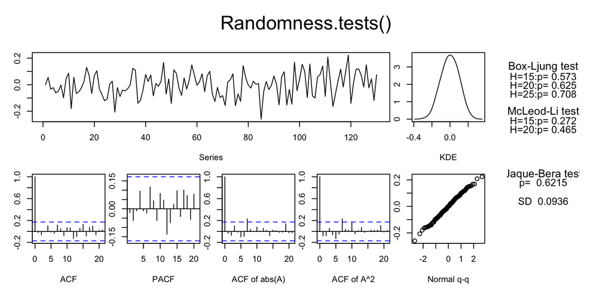

```
##   B-L test H0: the series is uncorrelated
##   M-L test H0: the square of the series is uncorrelated
##   J-B test H0: the series came from Normal distribution
##   SD         : Standard Deviation of the series
```

```
##       BL15  BL20  BL25  ML15  ML20    JB    SD
## [1,] 0.573 0.625 0.708 0.272 0.465 0.622 0.094
```

```r
Randomness.tests(FitB1$residuals)
```

```r
  ## ARIMA(1,1,3) with drift looks good.  All Param significant.  AICc=-231.66


Arima(Y, order=c(1,1,4), include.drift=TRUE)
```

```
## Series: Y
## ARIMA(1,1,4) with drift
##
## Coefficients:
##          ar1     ma1      ma2      ma3     ma4   drift
##       -0.853  0.3700  -0.6445  -0.2450  0.0983  0.0065
## s.e.   0.172  0.1961   0.1152   0.0933  0.1030  0.0026
##
## sigma^2 = 0.009127:  log likelihood = 122.56
## AIC=-231.12   AICc=-230.19   BIC=-211.1
```

```r
  ## Now MA4 is insignificant.
FitB3 = Arima(Y, order=c(2,1,3), include.drift=TRUE)
FitB3
```

```
## Series: Y
## ARIMA(2,1,3) with drift
##
## Coefficients:
##           ar1      ar2     ma1     ma2      ma3   drift
##       -0.5415  -0.7359  0.0448  0.2622  -0.5719  0.0064
## s.e.   0.2815   0.1276  0.2571  0.1112   0.1534  0.0027
##
## sigma^2 = 0.009045:  log likelihood = 123.07
## AIC=-232.15   AICc=-231.22   BIC=-212.13
```

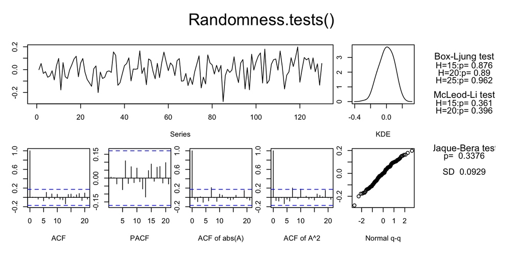

```
##   B-L test H0: the series is uncorrelated
##   M-L test H0: the square of the series is uncorrelated
##   J-B test H0: the series came from Normal distribution
##   SD         : Standard Deviation of the series
```

```
##       BL15 BL20  BL25  ML15  ML20    JB    SD
## [1,] 0.876 0.89 0.962 0.361 0.396 0.338 0.093
```

```r
Randomness.tests(FitB3$residuals)
```

```r
  ## AR2 is significant.  But MA1 is not.  AICc -231.22
```

## c) Fit a linear trend

to the undifferenced data using lm(). How is the fit of [linear trend + stationary error] model to this data?

```r
Reg1 = lm(Y ~ time(Y))
Stationarity.tests(Reg1$residuals)
```

```
##        KPSS   ADF   PP
## p-val:  0.1 0.706 0.01
```

```r
  ## ADF test says residuals are not statonary.
  ## [LT + Xt] model does not look good.
```

## d) What can you say about the form of the trend

in the data from what you see in (b) and (c)? Do you support deterministic trend or random trend for the model of this data?

Because of (c), we have to go with ARIMA(p,1,q) model from (b), which implies that the trend is random rather than deterministic.

## e) State the name of your final model in your R script.

(e.g. Fit1, Fit2, etc.) Express it using mathematical equations, using as original observations. List all parameters and their estimates.

```r
##N#  My Final model is FitB1, which is ARIMA(1,1,3) w drift. Because it has
## all parameters significant and is with lower AICc.
## ARIMA(2,1,3) is arguablly better model, because AR2 there is significant.
## However, this model has MA1 insignificant.
## For forecasting pourpose, the two models will produces similar result.

FitB1
```

```
## Series: Y
## ARIMA(1,1,3) with drift
##
## Coefficients:
##           ar1     ma1      ma2      ma3   drift
##       -0.9376  0.4846  -0.6341  -0.2857  0.0065
## s.e.   0.0946  0.1165   0.0955   0.0866  0.0025
##
## sigma^2 = 0.009108:  log likelihood = 122.17
## AIC=-232.34   AICc=-231.66   BIC=-215.19
```

```r
##N#  Final Model is ARMA(1,1,3) w drift.
###  Y_t = observation
###  Y_t = W_t + X'_t   where W_t is RW with drift (delta)
###  X_t = Y_t - Y_{t-1} + delta
###  X_t = (phi1) X_{t-1} + e_t + (theta1) e_{t-1} + (theta2) e_{t-2} + (theta3) e_{t-3}
###  e_t = WN(0, sigma)
###
###
###  delta_hat 0.0065
###  phi1_hat  -0.9376
###  the1_hat   0.4846
###  the2_hat  -0.6341
###  the3_hat  -0.2857
###  sigma_hat  sqrt(0.009108) = 0.0954358
```

## f) Perform static 50-step prediction,

and plot the result using your final model.

```r
forecast(FitB1, 50)
```

```
##     Point Forecast     Lo 80     Hi 80     Lo 95     Hi 95
## 131      0.5501725 0.4278654 0.6724796 0.3631199 0.7372251
## 132      0.5677318 0.4283238 0.7071397 0.3545257 0.7809378
## 133      0.5423910 0.3969951 0.6877869 0.3200272 0.7647549
## 134      0.5786710 0.4301391 0.7272029 0.3515111 0.8058310
## 135      0.5571733 0.4031887 0.7111578 0.3216742 0.7926723
## 136      0.5898500 0.4327760 0.7469240 0.3496260 0.8300739
## 137      0.5717308 0.4096400 0.7338215 0.3238343 0.8196272
## 138      0.6012396 0.4361046 0.7663747 0.3486873 0.8537919
## 139      0.5860907 0.4163001 0.7558813 0.3264184 0.8457630
## 140      0.6128145 0.4400242 0.7856047 0.3485546 0.8770743
## 141      0.6002770 0.4231348 0.7774191 0.3293614 0.8711925
## 142      0.6245522 0.4444550 0.8046494 0.3491173 0.8999871
## 143      0.6143105 0.4301197 0.7985013 0.3326150 0.8960061
## 144      0.6364331 0.4493318 0.8235344 0.3502864 0.9225798
```

[output cut: 36 more lines]

## g) Perform retroactive rolling 1-step prediction

for the last 20 observations of the data using your final model. Comment on the prediction performance.

```r
Pred = Rolling1step.forecast(Y,
                             window.size=110,
                             Arima.order=c(1,1,3),
                             include.drift=TRUE)
```

```
##
##   Total length 130 , window size 110 .
##   Last 20 obs retrospectively forecasted with Rolling 1-step
##       prediction using same order and fized window size.
##
##   Average Prediction Error:  0.0427
##   root Mean Squared Error of Prediction:   0.1183
```

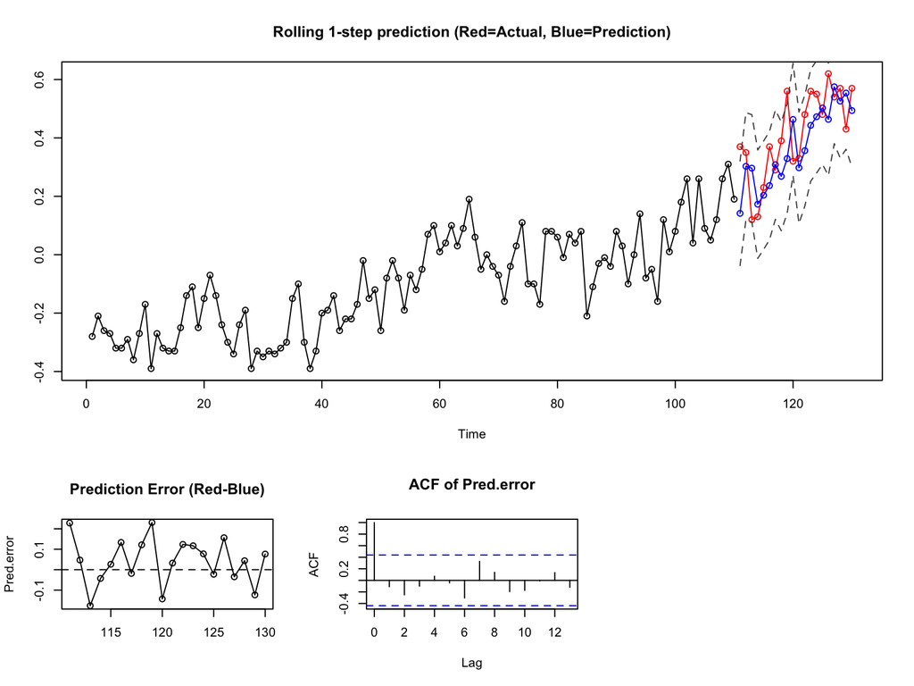

```r
Pred
```

```
## $Actual
## Time Series:
## Start = 111
## End = 130
## Frequency = 1
##  [1] 0.37 0.35 0.12 0.13 0.23 0.37 0.29 0.39 0.56 0.32 0.33 0.48 0.56 0.55 0.48 0.62 0.54
## [18] 0.57 0.43 0.57
##
## $Predicted
## Time Series:
## Start = 111
## End = 130
## Frequency = 1
##  [1] 0.1416072 0.3027663 0.2963890 0.1728909 0.2035855 0.2365305 0.3084231 0.2683458
##  [9] 0.3292417 0.4632116 0.2976370 0.3563367 0.4430193 0.4724956 0.5024892 0.4635183
## [17] 0.5750275 0.5260833 0.5535925 0.4936065
```

```r
##N#  rMSE of Prediction is 0.1183, which is close to
##   sigma_hat of 0.095435.  Prediction performance is consistent with the model.
##   Prediction errors are not showing any pattern.
##   If you use ARIMA(2,1,3), then rMSE is 0.1163
```